# Report

XihaoCao

2021/12/9

# Abstract

# Introduction

A Big Data company has set up a series of data scientist training courses, and it wants to hire candidates who have successfully passed those courses. However, not all people want to quit their current jobs after the training, and the company wants to know which of these candidates are looking for a job change. Thus I will try to understand the factors, ex: their education level, previous experience, training hours, that lead candidates to quit their jobs. If we can build a efficient model to predict the probability that a candidate looks for a job change, we can help the company to reduce the cost and time planning the courses and categorization of candidates, and allow the employee to make better decisions.

# Data Resource

# Missing data

The missing values in the data set are assigned a blank value rather than NA, in order to visualize and process easier, I replace all the missing value by a ‘NA’ string. And since all columns in the data set are stored as in the character type, I factorize all the columns that are not continuous to prepare for the model establishment.

# EDA

Before I build the model, I conduct the exploratory data analysis to have a better understanding of the data set.

Then I plot the number of candidates in each gender group, as we can see that almost 70% candidate are male, and we also have over 4500 missing values. Since the data set is imbalanced within the gender variable and the gender is commonly prohibited to be a admission factor, I will not include gender as a predictor in the model.

Here I explore the size of each education level, and we can notice that 61% of the candidate hold a graduate degree.

As we can see that distributions of training hours of candidates both take the offer and not share almost the same shape. Thus we can conclude that the training hours has little impact on candidate’ final decisions, and I will not include the training hours in my model.

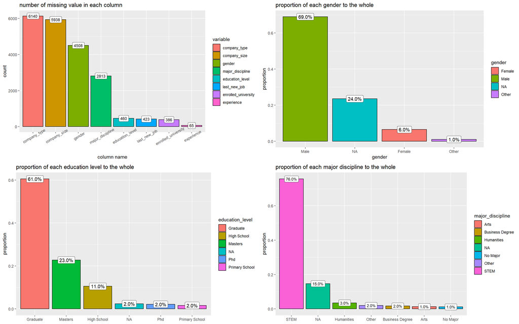

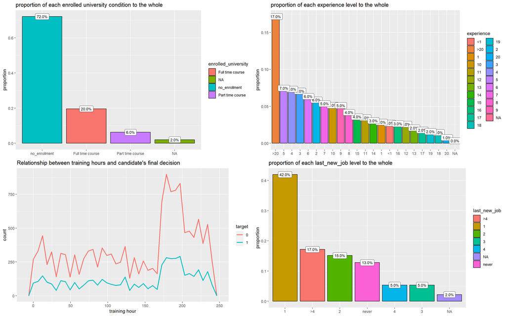